# Data table preparation and MAGEcK Analysis for B-ALL

Charlie Whittaker

1/23/2023

# Load libraries

```r
library(openxlsx)
library(ggplot2)
library(tidyverse)
library(cowplot)
library(VennDiagram)
library(ggVennDiagram)
library(reprex)
library(matrixStats)
library(XML)
library(ggrepel)
library(ggpubr)
library(GGally)
library(DESeq2)
library(apeglm)
library(ComplexHeatmap)
library(dplyr)
library(readxl)
library(readr)
library(tximport)
library(edgeR)
library(MAGeCKFlute)
library(gprofiler2)
library(clusterProfiler)
library(fgsea)
```

# Import local code

```r
source('Rcode/data_formatting_tools.R')
source('Rcode/analysis_tools.R')
source('Rcode/plots.R')
source('Rcode/common.R')
source('Rcode/ssGSEAProjection.Library.R')
source('Rcode/gostplot_v2.R')
```

# Reading data

## Barcode Annotation file

This file is similar to sgRNAs but has some additional information

This can be adjusted in various ways. For example, when count of GeneSym is greater than 1, output will include results that are not official symbols.

```r
BarcodeAnnotations <- read_excel("BarcodeAnnotations.xlsx")
GeneSymWhitelist.selection <- BarcodeAnnotations %>% filter(NegativeControlGroup == 'No' &
                                                    CountOfGeneSym <= 1 &
                                                    GeneTargetInMultiplePools == 'No' &
                                                    between(BarcodesPerGene, 3,4))

GeneSymWhitelist <- unique(GeneSymWhitelist.selection %>% select(GeneSym,Pool)) %>% mutate(geneSym.whitelist = 'Yes')
#write.xlsx(GeneSymWhitelist,file='GeneSymWhitelist.xlsx')
```

## Read in sgRNA annotation file

This is used in the processing of the counts- files

```r
sgRNAs <- read.xlsx("../sgRNA_to_Gene_stock_plusPool.xlsx")
sgRNAs.gene <- sgRNAs %>% select(c("Barcode.Sequence","GeneSym","Pool"))
```

## Essential Genes

```r
hart <- read.xlsx("../Documents/hart_essential_MGI.xlsx")
essentialGenes <- read_xlsx("../Documents/essential_genes_combined_mouseSyms.xlsx")
```

## Mouse Gene to KEGG

The human MsigDB Kegg GMT file was combined with MGI mouse to human orthogy data to build a table that associates mouse symbols with a yes/no KEGG flag. This will allow us to highlight genes associated with some KEGG term in later plots.

```r
mmKEGG <- read_excel("../Documents/Mm_GeneSym_KEGG_association.xlsx")
mmKEGG.toJoin <- mmKEGG %>% select(MmSym,KEGG_Flag) %>% filter(KEGG_Flag == 'yes')
```

## Import IFNG sets

```r
biocarta.ifng <-read_excel("../Documents/BIOCARTA_IFNG_PATHWAY.xlsx")
hallmark.ifng <-read_excel("../Documents/HALLMARK_INTERFERON_GAMMA_RESPONSE.xlsx")
```

## Useful functions

```r
rowCount <- function(dat.table){
  as.data.frame(sapply(dat.table, length))
}

p1log2 <- function(dat.table){
  log2(dat.table+1)
}

summarizePool <- function(tt){
  tt <- merge(x=tt,y=sgRNAs.gene, by.x=c("Construct.Barcode"),by.y=c("Barcode.Sequence"), all=FALSE, all.x=TRUE)
  poolOut <-c()
  for (s in colnames(tt)){
    tmp <- tt %>% select(c("Construct.Barcode",s,"Pool"))
    tmp <- tmp %>% filter(!is.na(tmp[,s]))
    poolCt <- as.data.frame(table(tmp$Pool))
    poolOut <- rbind(poolOut,cbind(poolCt))
  }
  return(poolOut)
}

read_mageck_output <- function(outbase){
  print(outbase)
  assign(paste0(outbase,".gdata"),ReadRRA(paste0(outbase,".gene_summary.txt"), score = c("lfc", "rra")[1]))
  assign(paste0(outbase,".sdata"),ReadsgRRA(paste0(outbase,".sgrna_summary.txt")))
}

plot_gdata_volcano <- function(gdata){
  VolcanoView(gdata, x = "Score", y = "FDR", top = 10,
                 alpha=1, x_cutoff = log2(1.38), y_cutoff = 0.5,
                 mycolour = c("darkgrey", "#e41a1c", "#377eb8"),
                 ylab = "-Log10(FDR)", Label = "id") + ggtitle(i)
}

plot_essentials <- function(gdata.df){
  toPlot <- merge(x=gdata.df, y=hart, by.x="id" ,by.y="MGISym", all.x=TRUE)
  essential <- toPlot %>% filter(toPlot$hart_essential == "Y")
  degPlot <- ggplot() +
    geom_point(data=toPlot, aes(x=Score, y=-log10(FDR)), col="grey") +
    geom_point(data=essential, aes(x=Score, y=-log10(FDR)), col="red") +
    theme_bw() + theme(panel.border = element_blank(), panel.grid.major = element_blank(),
                       panel.grid.minor = element_blank(), axis.line = element_line(colour = "black"))
  return(degPlot)
}

vlnplot_essentials <- function(df){
  Essential.toPlot <- merge(x=df, y=essentialGenes, by.x="id" ,by.y="MGISym", all.x=TRUE)
  Essential.toPlot <- merge(x=Essential.toPlot, y=GeneSymWhitelist, by.x="id" ,by.y="GeneSym", all.x=TRUE)
  Essential.toPlot <- Essential.toPlot %>% mutate(Essential = ifelse(is.na(Essential), "No", Essential))
  Essential.toPlot <- Essential.toPlot %>% dplyr::filter(geneSym.whitelist == "Yes")
  Essential.toPlot <- Essential.toPlot %>% rename(LFC = Score)
  data <- Essential.toPlot
  plot <- ggplot(data, aes(factor(Essential), LFC)) + geom_violin(fill='#A4A4A4') + geom_boxplot(width=.1) + ylim(-2.5, 2.5) +
    theme_bw() +
    theme(plot.title = element_text(size = 8),axis.title.x = element_text(size = 8),axis.title.y = element_text(size = 8))
  return(plot)
}
```

## Importing Screen Count data from Broad files for Re-analysis

```r
dir1 = "../200406/filesTogether/"
#list.files(dir1,"counts")

dir2 = "../200627/filesTogether/"
#list.files(dir2,"counts")

dir3 = "../RH_resequenced_counts_files/"

files1 <- list.files(dir1,pattern="counts-*", full.names=TRUE)
files2 <- list.files(dir2,pattern="counts-*", full.names=TRUE)
files3 <- list.files(dir3,pattern="counts-*", full.names=TRUE)
```

```r
ldf.200406 <- lapply(files1, read.delim)
ldf.200627 <- lapply(files2, read.delim)
ldf.RH <- lapply(files3, read.delim)
```

## extract column names for the imported data and build dataframe that associated these values with a folder.object.file Index

```r
importedNames <- c()

for (i in 1:length(ldf.200406)){
  folder <- "200406"
  name <- colnames(ldf.200406[[i]])
  name <- as.data.frame(name)
  name <- tibble::rownames_to_column(name, "FileIndex")
  importedNames <- rbind(importedNames,cbind(Fold.Obj=paste0(folder,".",i),name))
}

for (i in 1:length(ldf.200627)){
  folder <- "200627"
  name <- colnames(ldf.200627[[i]])
  name <- as.data.frame(name)
  name <- tibble::rownames_to_column(name, "FileIndex")
  importedNames <- rbind(importedNames,cbind(Fold.Obj=paste0(folder,".",i),name))
}

for (i in 1:length(ldf.RH)){
  folder <- "RH"
  name <- colnames(ldf.RH[[i]])
  name <- as.data.frame(name)
  name <- tibble::rownames_to_column(name, "FileIndex")
  importedNames <- rbind(importedNames,cbind(Fold.Obj=paste0(folder,".",i),name))
}

importedNames <- importedNames %>% mutate(Folder.Obj.File_Index=paste0(Fold.Obj,".",FileIndex))
importedNames <- importedNames %>% select(name,Folder.Obj.File_Index)
```

## calculate medians, row counts and numbers of zeros

```r
List.Stats <- c()

for (i in 1:length(ldf.200406)){
  folder <- "200406"
  tmp.df <- mutate_if(ldf.200406[[i]], is.numeric, p1log2)
  List.Med <- as.data.frame(sapply(tmp.df, median))
  List.Med <- rename(List.Med, l2.median = `sapply(tmp.df, median)`)
  List.RowCount <- rowCount(ldf.200406[[i]])
  List.RowCount <- rename( List.RowCount, Row.Count = `sapply(dat.table, length)`)
  List.Zeros <- as.data.frame(colSums(ldf.200406[[i]]==0))
  List.Zeros <- rename(List.Zeros, ZeroCount = `colSums(ldf.200406[[i]] == 0)`)
  List.RowNumber <- as.data.frame(1:nrow(List.Med))
  List.RowNumber <- rename(List.RowNumber, FileIndex = `1:nrow(List.Med)`)
  List.Stats <- rbind(List.Stats,cbind(List.RowNumber,folder,i,List.Med,List.RowCount,List.Zeros))
}

for (i in 1:length(ldf.200627)){
  folder <- "200627"
  tmp.df <- mutate_if(ldf.200627[[i]], is.numeric, p1log2)
  List.Med <- as.data.frame(sapply(tmp.df, median))
  List.Med <- rename(List.Med, l2.median = `sapply(tmp.df, median)`)
  List.RowCount <- rowCount(ldf.200627[[i]])
  List.RowCount <- rename( List.RowCount, Row.Count = `sapply(dat.table, length)`)
  List.Zeros <- as.data.frame(colSums(ldf.200627[[i]]==0))
  List.Zeros <- rename(List.Zeros, ZeroCount = `colSums(ldf.200627[[i]] == 0)`)
  List.RowNumber <- as.data.frame(1:nrow(List.Med))
  List.RowNumber <- rename(List.RowNumber, FileIndex = `1:nrow(List.Med)`)
  List.Stats <- rbind(List.Stats,cbind(List.RowNumber,folder,i,List.Med,List.RowCount,List.Zeros))
}

for (i in 1:length(ldf.RH)){
  folder <- "RH"
  tmp.df <- mutate_if(ldf.RH[[i]], is.numeric, p1log2)
  List.Med <- as.data.frame(sapply(tmp.df, median))
  List.Med <- rename(List.Med, l2.median = `sapply(tmp.df, median)`)
  List.RowCount <- rowCount(ldf.RH[[i]])
  List.RowCount <- rename( List.RowCount, Row.Count = `sapply(dat.table, length)`)
  List.Zeros <- as.data.frame(colSums(ldf.RH[[i]]==0))
  List.Zeros <- rename(List.Zeros, ZeroCount = `colSums(ldf.RH[[i]] == 0)`)
  List.RowNumber <- as.data.frame(1:nrow(List.Med))
  List.RowNumber <- rename(List.RowNumber, FileIndex = `1:nrow(List.Med)`)
  List.Stats <- rbind(List.Stats,cbind(List.RowNumber,folder,i,List.Med,List.RowCount,List.Zeros))
}

List.Stats <- rename(List.Stats, ObjIndex = `i`)
List.Stats <- List.Stats %>% mutate(Folder.Obj.File_Index=paste0(folder,".",ObjIndex,".",FileIndex))
List.Stats <- List.Stats %>% select(Folder.Obj.File_Index,l2.median,Row.Count,ZeroCount)
```

## Summarize Pool per sample

```r
poolSummary <- c()

for (i in 1:length(ldf.200406)){
  folder <- "200406"
  poolCt <- summarizePool(ldf.200406[[i]])
  poolCt <- tibble::rownames_to_column(poolCt, "FileIndex")
  poolSummary <- rbind(poolSummary,cbind(Fold.Obj=paste0(folder,".",i),poolCt))
}

for (i in 1:length(ldf.200627)){
  folder <- "200627"
  poolCt <- summarizePool(ldf.200627[[i]])
  poolCt <- tibble::rownames_to_column(poolCt, "FileIndex")
  poolSummary <- rbind(poolSummary,cbind(Fold.Obj=paste0(folder,".",i),poolCt))
}

for (i in 1:length(ldf.RH)){
  folder <- "RH"
  poolCt <- summarizePool(ldf.RH[[i]])
  poolCt <- tibble::rownames_to_column(poolCt, "FileIndex")
  poolSummary <- rbind(poolSummary,cbind(Fold.Obj=paste0(folder,".",i),poolCt))
}

poolSummary <- rename(poolSummary, DetectedPool = Var1)
poolSummary <- poolSummary %>% mutate(Folder.Obj.File_Index=paste0(Fold.Obj,".",FileIndex))
poolSummary <- poolSummary %>% select(Folder.Obj.File_Index,DetectedPool,Freq)
```

```r
qcObject <- merge(x=importedNames,y=List.Stats, by.x='Folder.Obj.File_Index',by.y='Folder.Obj.File_Index', all=TRUE)
qcObject <- merge(x=qcObject,y=poolSummary, by.x='Folder.Obj.File_Index',by.y='Folder.Obj.File_Index', all=FALSE,all.x=TRUE)
write.xlsx(qcObject,file="qcObject_plusRH.xlsx")
```

# Building dataframes for mageck testing, running tests and importing results

There are numerous pools and conditions to compare and columns containing the data are scattered in the 91 input files. These commands extract, assembly and re-order each set of columns. Data are then exported for mageck testing and results are imported.

# In vitro

## In Vitro Pool A

identify columns with non-0 medians

```r
invitro.poolA.1 <- ldf.200406[[1]][c(1,6,15,16,17,18,19,20)]
invitro.poolA.2 <- ldf.200406[[7]][c(1,8,9,10,11,12,13,26)]
invitro.poolA.3 <- ldf.200627[[61]][c(1,3)]

invitro.poolA <- merge(x=invitro.poolA.1,y=invitro.poolA.2, by.x=c("Construct.Barcode"),by.y=c("Construct.Barcode"), all=TRUE)
invitro.poolA <- merge(x=invitro.poolA,y=invitro.poolA.3, by.x=c("Construct.Barcode"),by.y=c("Construct.Barcode"), all=TRUE)
invitro.poolA <- merge(x=invitro.poolA,y=sgRNAs.gene, by.x=c("Construct.Barcode"),by.y=c("Barcode.Sequence"), all=FALSE, all.x=TRUE)

col.vit.poolA <- colnames(invitro.poolA)
```

```r
# reorder columns
invitro.poolA.reorder <- invitro.poolA[,c(1,17,2,15,
                                          3,4,5,16,
                                          6,7,8,
                                          9,10,11,
                                          12,13,14)]
# replace NA values with 0
invitro.poolA.reorder <- replace(invitro.poolA.reorder, is.na(invitro.poolA.reorder), 0)
# Write to table for mageck run
write_delim(invitro.poolA.reorder,file="invitro.poolA.txt", delim = '\t')
```

### results import and plotting

```r
files.toPlot <- list.files(pattern=glob2rx("invitro.poolA_*gene_summary.txt"), full.names=FALSE)
files.toPlot <- str_replace(files.toPlot, ".gene_summary.txt", "")
files.toPlot
```

```
## [1] "invitro.poolA_all_v_input"
## [2] "invitro.poolA_hEGFRv3.CAR_ET.1.10_v_input"
## [3] "invitro.poolA_mCD19.CAR_ET.1.10_v_hEGFRv3.CAR_ET.1.10"
## [4] "invitro.poolA_mCD19.CAR_ET.1.2_v_hEGFRv3.CAR_ET.1.2"
```

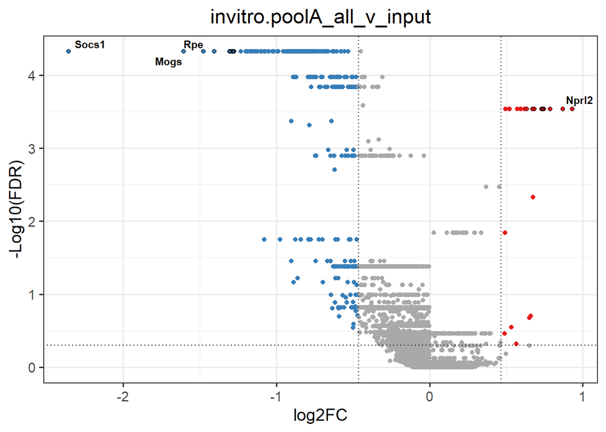

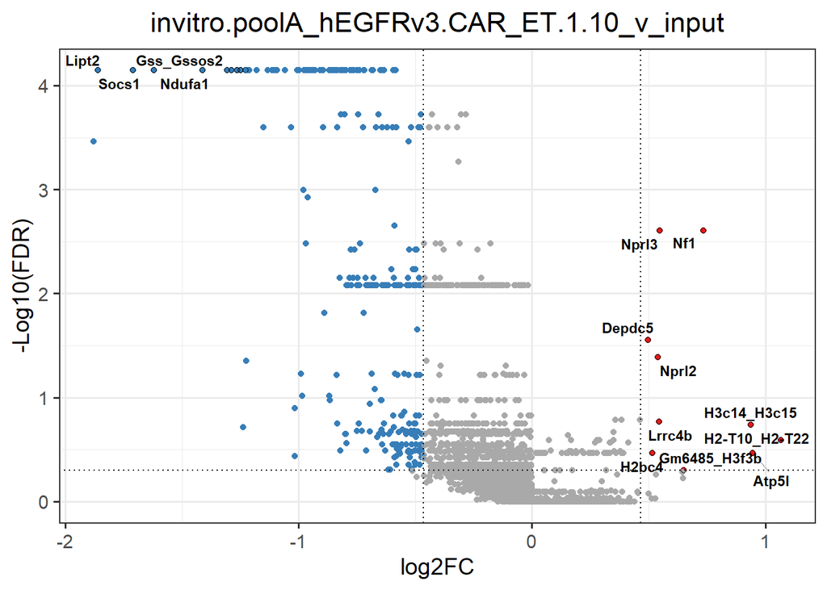

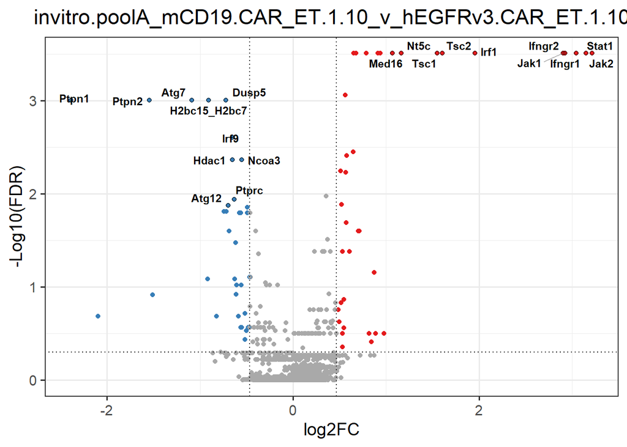

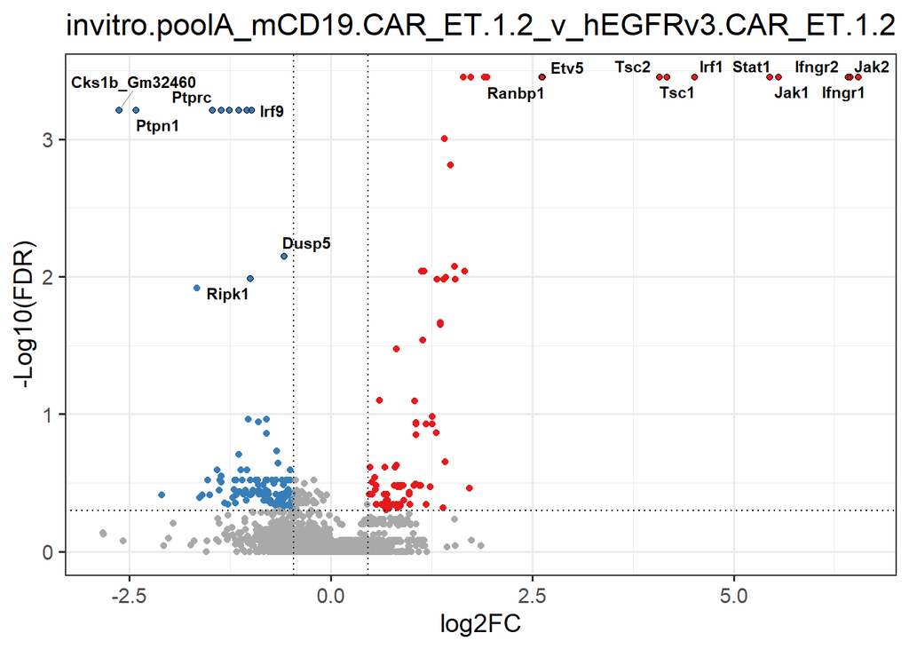

```r
for (i in files.toPlot){
  assign(paste0(i,".gdata"),ReadRRA(paste0(i,".gene_summary.txt"), score = c("lfc", "rra")[1]))
  assign(paste0(i,".sdata"),ReadsgRRA(paste0(i,".sgrna_summary.txt")))
}

for (i in files.toPlot){
  x <- get(paste0(i,".gdata"))
  print(plot_gdata_volcano(x))
}
```

## In Vitro Pool B

identify columns with non-0 medians

```r
invitro.poolB.1 <- ldf.200406[[4]][c(1,7,21,22,23,25,26)]
invitro.poolB.2 <- ldf.200406[[9]][c(1,14,15,16,17,18,27)]
invitro.poolB.3 <- ldf.200627[[63]][c(1,4,5)]

invitro.poolB <- merge(x=invitro.poolB.1,y=invitro.poolB.2, by.x=c("Construct.Barcode"),by.y=c("Construct.Barcode"), all=TRUE)
invitro.poolB <- merge(x=invitro.poolB,y=invitro.poolB.3, by.x=c("Construct.Barcode"),by.y=c("Construct.Barcode"), all=TRUE)
#invitro.poolB <- merge(x=invitro.poolB,y=invitro.poolB.4, by.x=c("Construct.Barcode"),by.y=c("Construct.Barcode"), all=TRUE)
invitro.poolB <- merge(x=invitro.poolB,y=sgRNAs.gene, by.x=c("Construct.Barcode"),by.y=c("Barcode.Sequence"), all=FALSE, all.x=TRUE)

col.vit.poolB <- colnames(invitro.poolB)
```

```r
# reorder columns

invitro.poolB.reorder <- invitro.poolB[,c(1,16,2,
                                          13,
                                          3,4,5,
                                          6,7,14,
                                          8,9,10,15,
                                          11,12)]

# replace NA values with 0
invitro.poolB.reorder <- replace(invitro.poolB.reorder, is.na(invitro.poolB.reorder), 0)

# Write to table for mageck run
write_delim(invitro.poolB.reorder,file="invitro.poolB.txt", delim = '\t')
```

### results import and plotting

```r
files.toPlot <- list.files(pattern=glob2rx("invitro.poolB_*gene_summary.txt"), full.names=FALSE)
files.toPlot <- str_replace(files.toPlot, ".gene_summary.txt", "")
files.toPlot
```

```
## [1] "invitro.poolB_all_v_input"
## [2] "invitro.poolB_hEGFRv3.CAR_ET.1.10_v_input"
## [3] "invitro.poolB_mCD19.CAR_ET.1.10_v_hEGFRv3.CAR_ET.1.10"
## [4] "invitro.poolB_mCD19.CAR_ET.1.2_v_hEGFRv3.CAR_ET.1.2"
```

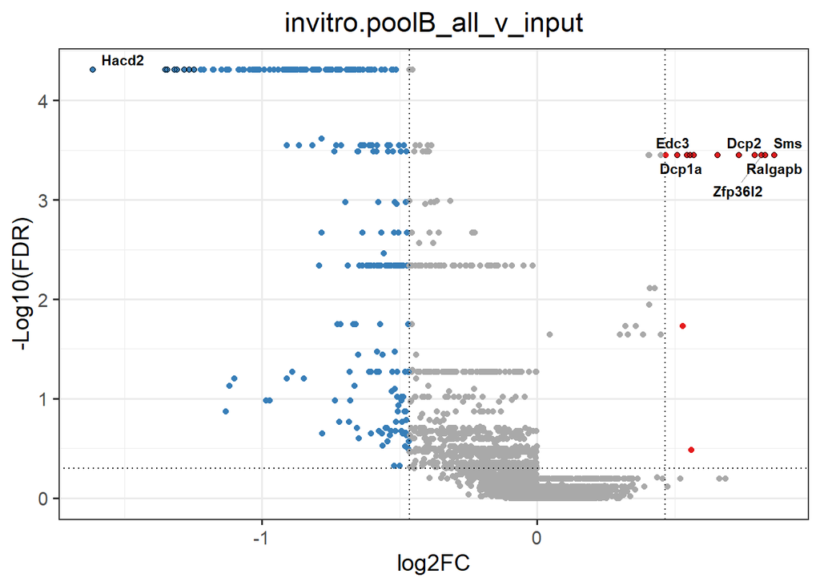

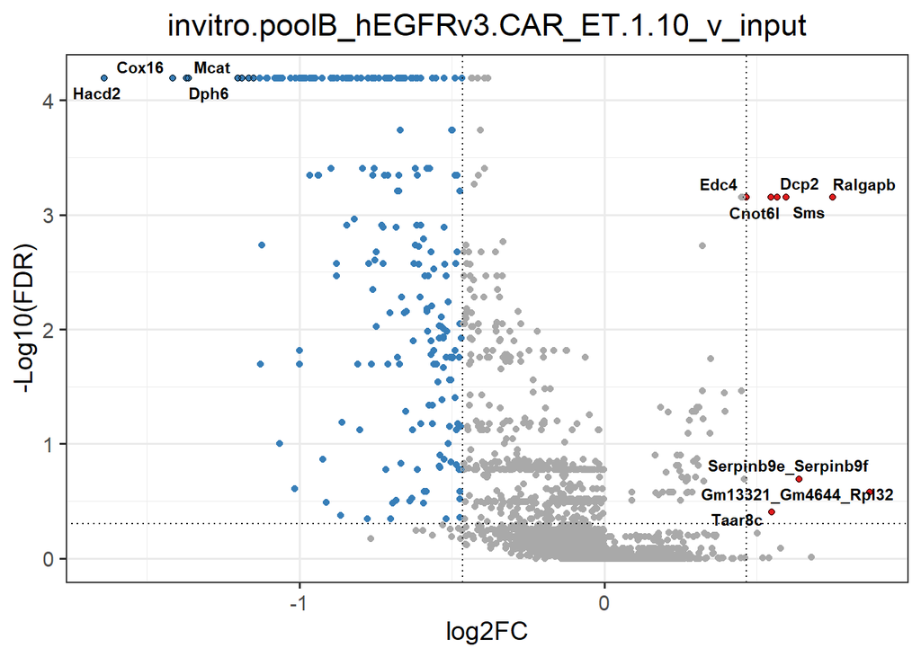

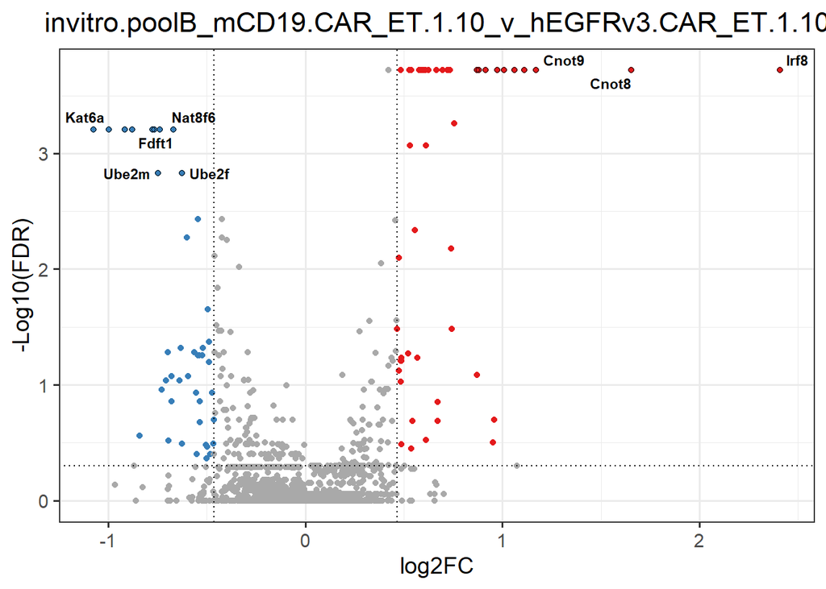

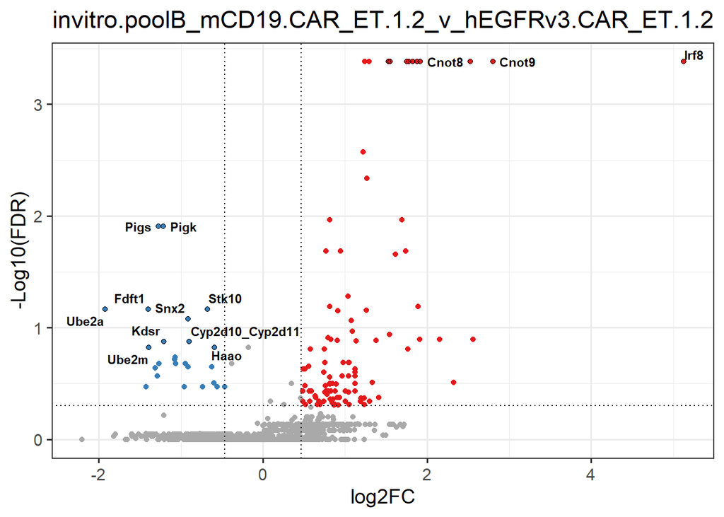

```r
for (i in files.toPlot){
  assign(paste0(i,".gdata"),ReadRRA(paste0(i,".gene_summary.txt"), score = c("lfc", "rra")[1]))
  assign(paste0(i,".sdata"),ReadsgRRA(paste0(i,".sgrna_summary.txt")))
}

for (i in files.toPlot){
  x <- get(paste0(i,".gdata"))
  print(plot_gdata_volcano(x))
}
```

## In Vitro Pool C

```r
invitro.poolC.1 <- ldf.200406[[2]][c(1,8,27)]
invitro.poolC.2 <- ldf.200406[[8]][c(1,3,4,5,6,7,20,21,22,23,24,25)]
invitro.poolC.3 <- ldf.200406[[10]][c(1,3)]

invitro.poolC <- merge(x=invitro.poolC.1,y=invitro.poolC.2, by.x=c("Construct.Barcode"),by.y=c("Construct.Barcode"), all=TRUE)
invitro.poolC <- merge(x=invitro.poolC,y=invitro.poolC.3, by.x=c("Construct.Barcode"),by.y=c("Construct.Barcode"), all=TRUE)
invitro.poolC <- merge(x=invitro.poolC,y=sgRNAs.gene, by.x=c("Construct.Barcode"),by.y=c("Barcode.Sequence"), all=FALSE, all.x=TRUE)

col.vit.poolC <- colnames(invitro.poolC)
```

```r
# reorder columns
invitro.poolC.reorder <- invitro.poolC[,c(1,16,2,15,
                                  3,4,5,
                                  6,7,8,
                                  9,10,11,
                                  12,13,14)]

# replace NA values with 0
invitro.poolC.reorder <- replace(invitro.poolC.reorder, is.na(invitro.poolC.reorder), 0)

# Write to table for mageck run
write_delim(invitro.poolC.reorder,file="invitro.poolC.txt", delim = '\t')
```

### results import and plotting

```r
files.toPlot <- list.files(pattern=glob2rx("invitro.poolC_*gene_summary.txt"), full.names=FALSE)
files.toPlot <- str_replace(files.toPlot, ".gene_summary.txt", "")
files.toPlot
```

```
## [1] "invitro.poolC_all_v_input"
## [2] "invitro.poolC_hEGFRv3.CAR_ET.1.10_v_input"
## [3] "invitro.poolC_mCD19.CAR_ET.1.10_v_hEGFRv3.CAR_ET.1.10"
## [4] "invitro.poolC_mCD19.CAR_ET.1.2_v_hEGFRv3.CAR_ET.1.2"
```

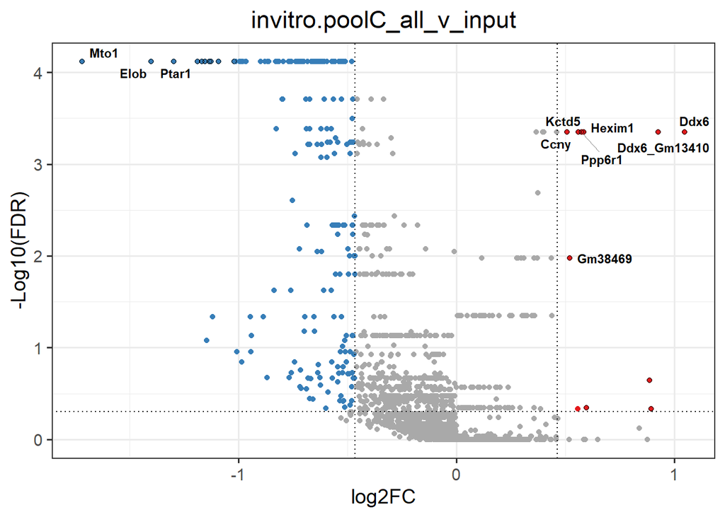

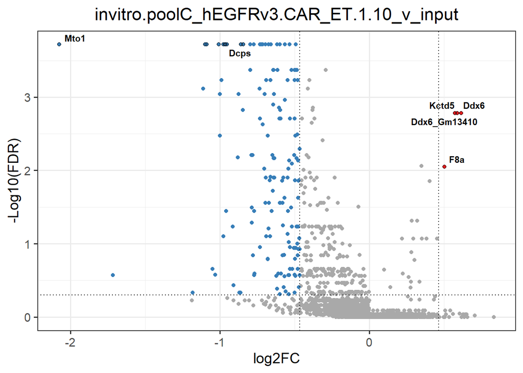

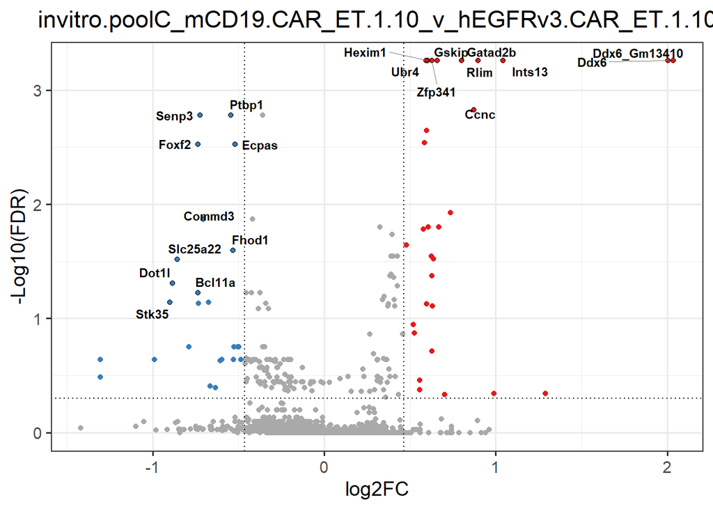

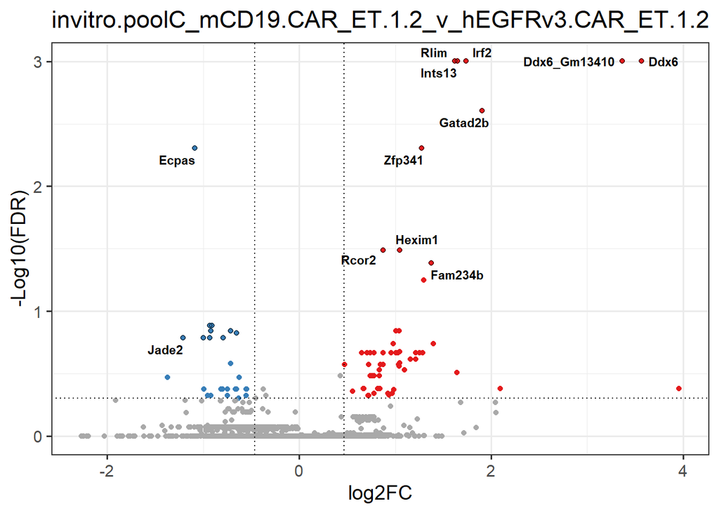

```r
for (i in files.toPlot){
  assign(paste0(i,".gdata"),ReadRRA(paste0(i,".gene_summary.txt"), score = c("lfc", "rra")[1]))
  assign(paste0(i,".sdata"),ReadsgRRA(paste0(i,".sgrna_summary.txt")))
}

for (i in files.toPlot){
  x <- get(paste0(i,".gdata"))
  print(plot_gdata_volcano(x))
}
```

## In Vitro Pool D

```r
invitro.poolD.1 <- ldf.200406[[3]][c(1,12)]
invitro.poolD.2 <- ldf.200406[[11]][c(1,4,5,6,7,8,9,18,19,20,21,22,23)]
invitro.poolD.3 <- ldf.200406[[15]][c(1,14)]

invitro.poolD <- merge(x=invitro.poolD.1,y=invitro.poolD.2, by.x=c("Construct.Barcode"),by.y=c("Construct.Barcode"), all=TRUE)
invitro.poolD <- merge(x=invitro.poolD,y=invitro.poolD.3, by.x=c("Construct.Barcode"),by.y=c("Construct.Barcode"), all=TRUE)
invitro.poolD <- merge(x=invitro.poolD,y=sgRNAs.gene, by.x=c("Construct.Barcode"),by.y=c("Barcode.Sequence"), all=FALSE, all.x=TRUE)

col.vit.poolD <- colnames(invitro.poolD)
```

```r
# reorder columns
invitro.poolD.reorder <- invitro.poolD[,c(1,16,2,15,
                                  3,4,5,
                                  6,7,8,
                                  9,10,11,
                                  12,13,14)]

# replace NA values with 0
invitro.poolD.reorder <- replace(invitro.poolD.reorder, is.na(invitro.poolD.reorder), 0)

# Write to table for mageck run
write_delim(invitro.poolD.reorder,file="invitro.poolD.txt", delim = '\t')
```

### results import and plotting

```r
files.toPlot <- list.files(pattern=glob2rx("invitro.poolD_*gene_summary.txt"), full.names=FALSE)
files.toPlot <- str_replace(files.toPlot, ".gene_summary.txt", "")
files.toPlot
```

```
## [1] "invitro.poolD_all_v_input"
## [2] "invitro.poolD_hEGFRv3.CAR_ET.1.10_v_input"
## [3] "invitro.poolD_mCD19.CAR_ET.1.10_v_hEGFRv3.CAR_ET.1.10"
## [4] "invitro.poolD_mCD19.CAR_ET.1.2_v_hEGFRv3.CAR_ET.1.2"
```

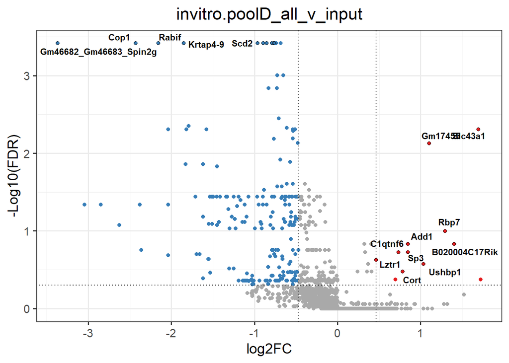

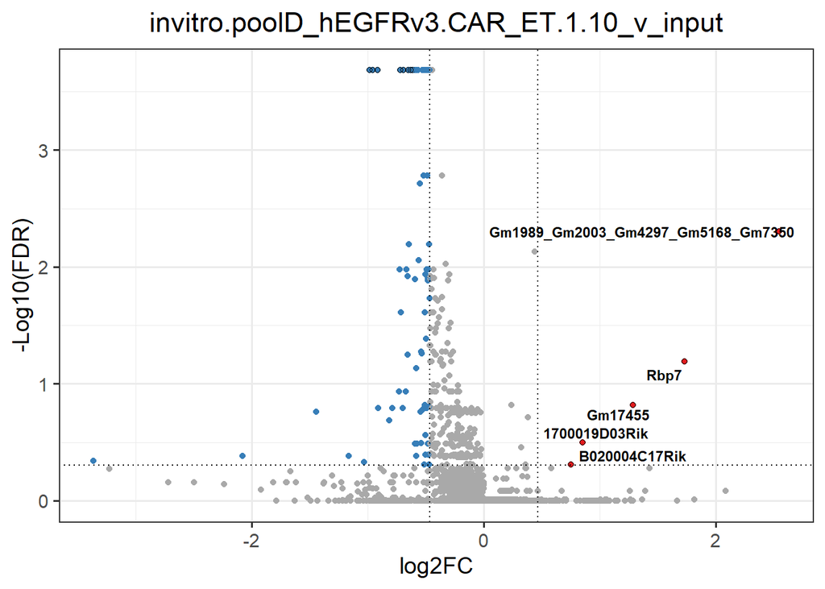

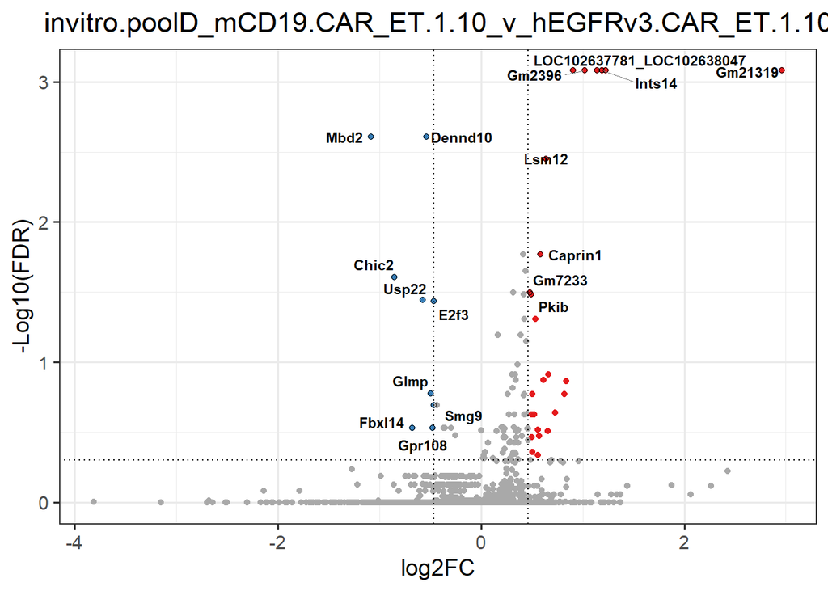

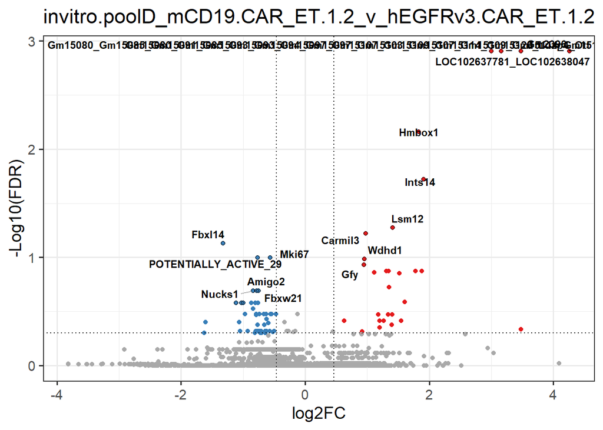

```r
for (i in files.toPlot){
  assign(paste0(i,".gdata"),ReadRRA(paste0(i,".gene_summary.txt"), score = c("lfc", "rra")[1]))
  assign(paste0(i,".sdata"),ReadsgRRA(paste0(i,".sgrna_summary.txt")))
}

for (i in files.toPlot){
  x <- get(paste0(i,".gdata"))
  print(plot_gdata_volcano(x))
}
```

## In Vitro Pool E

```r
invitro.poolE.1 <- ldf.200406[[5]][c(1,13)]
invitro.poolE.2 <- ldf.200406[[12]][c(1,10,11,12,13,14,24)]
invitro.poolE.3 <- ldf.200406[[16]][c(1,3,4,5,6,7,15)]

invitro.poolE <- merge(x=invitro.poolE.1,y=invitro.poolE.2, by.x=c("Construct.Barcode"),by.y=c("Construct.Barcode"), all=TRUE)
invitro.poolE <- merge(x=invitro.poolE,y=invitro.poolE.3, by.x=c("Construct.Barcode"),by.y=c("Construct.Barcode"), all=TRUE)
invitro.poolE <- merge(x=invitro.poolE,y=sgRNAs.gene, by.x=c("Construct.Barcode"),by.y=c("Barcode.Sequence"), all=FALSE, all.x=TRUE)

col.vit.poolE <- colnames(invitro.poolE)
```

```r
# reorder columns
invitro.poolE.reorder <- invitro.poolE[,c(1,15,2,14,
                                  3,4,
                                  5,6,7,
                                  8,9,10,
                                  11,12,13)]

# replace NA values with 0
invitro.poolE.reorder <- replace(invitro.poolE.reorder, is.na(invitro.poolE.reorder), 0)

# Write to table for mageck run
write_delim(invitro.poolE.reorder,file="invitro.poolE.txt", delim = '\t')
```

### results import and plotting

```r
files.toPlot <- list.files(pattern=glob2rx("invitro.poolE_*gene_summary.txt"), full.names=FALSE)
files.toPlot <- str_replace(files.toPlot, ".gene_summary.txt", "")
files.toPlot
```

```
## [1] "invitro.poolE_all_v_input"
## [2] "invitro.poolE_hEGFRv3.CAR_ET.1.10_v_input"
## [3] "invitro.poolE_mCD19.CAR_ET.1.10_v_hEGFRv3.CAR_ET.1.10"
## [4] "invitro.poolE_mCD19.CAR_ET.1.2_v_hEGFRv3.CAR_ET.1.2"
```

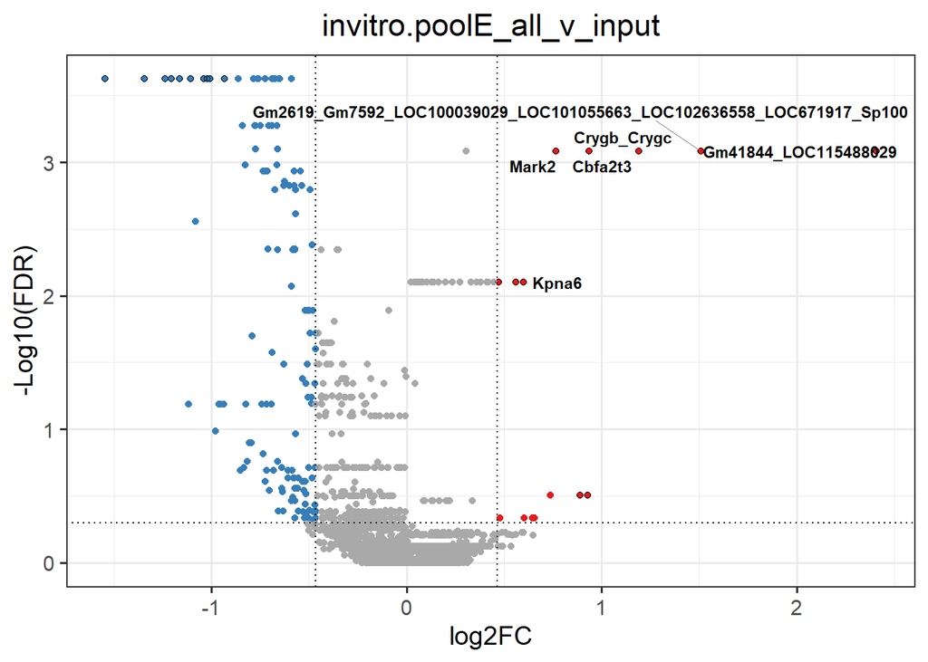

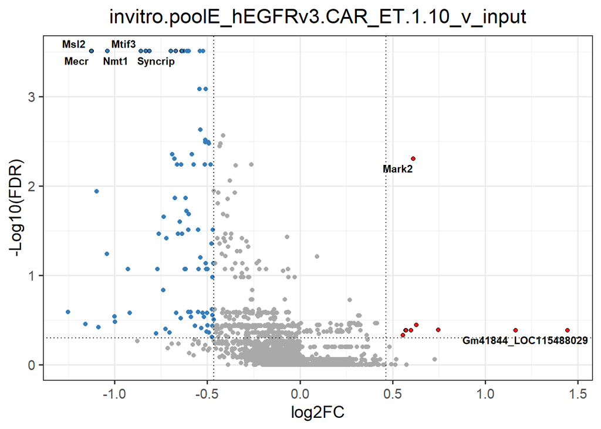

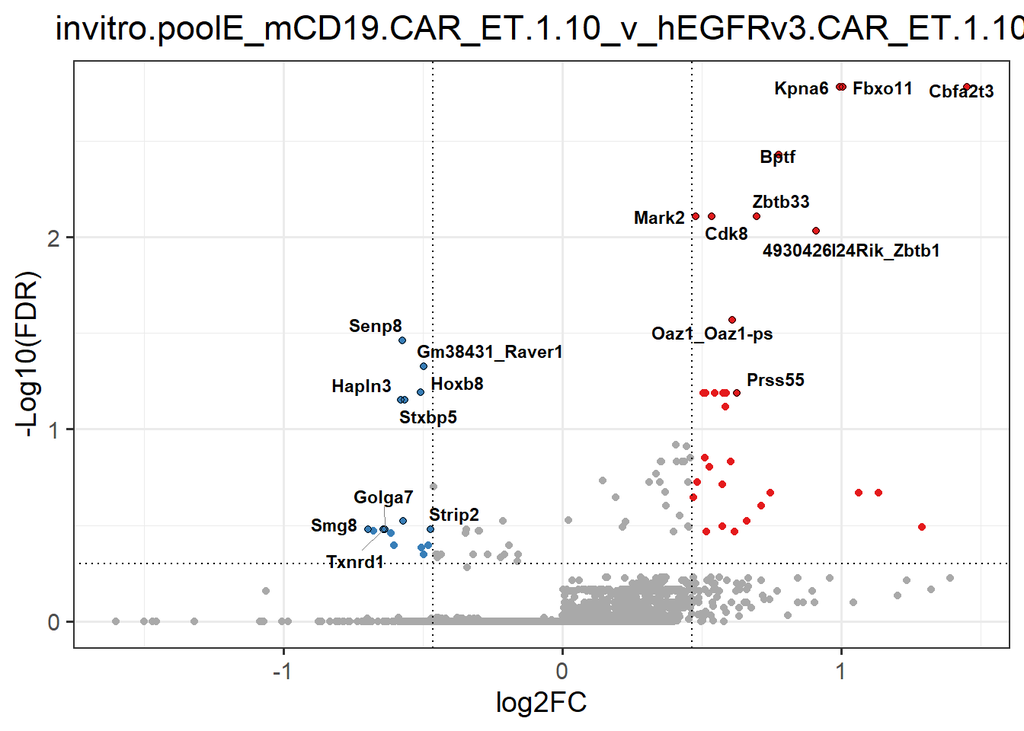

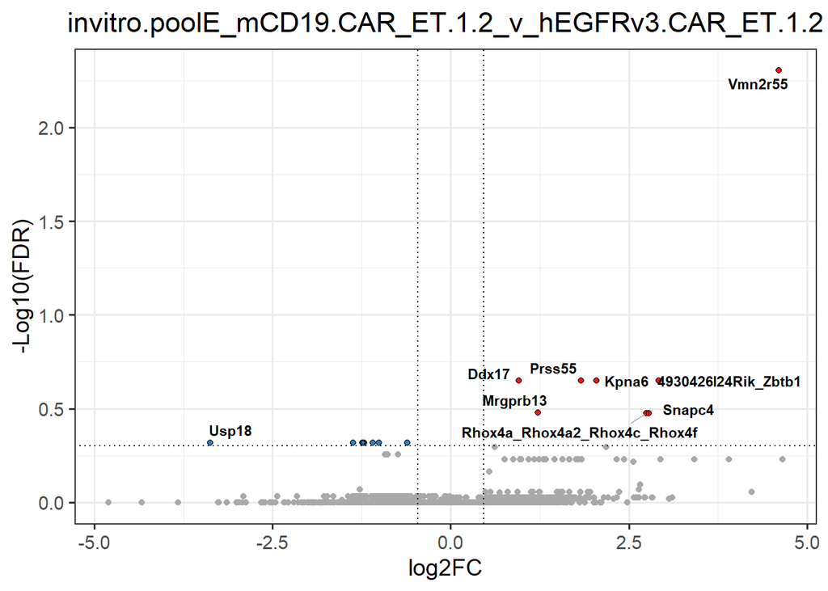

```r
for (i in files.toPlot){
  assign(paste0(i,".gdata"),ReadRRA(paste0(i,".gene_summary.txt"), score = c("lfc", "rra")[1]))
  assign(paste0(i,".sdata"),ReadsgRRA(paste0(i,".sgrna_summary.txt")))
}

for (i in files.toPlot){
  x <- get(paste0(i,".gdata"))
  print(plot_gdata_volcano(x))
}
```

## In Vitro Pool F

```r
invitro.poolF.1 <- ldf.200406[[6]][c(1,14)]
invitro.poolF.2 <- ldf.200406[[13]][c(1,15,16,17)]
invitro.poolF.3 <- ldf.200406[[17]][c(1,8,9,10,11,16)]
invitro.poolF.4 <- ldf.200627[[64]][c(1,7,8)]
invitro.poolF.5 <- ldf.RH[[3]][c(1,3,4,5)]

invitro.poolF <- merge(x=invitro.poolF.1,y=invitro.poolF.2, by.x=c("Construct.Barcode"),by.y=c("Construct.Barcode"), all=TRUE)
invitro.poolF <- merge(x=invitro.poolF,y=invitro.poolF.3, by.x=c("Construct.Barcode"),by.y=c("Construct.Barcode"), all=TRUE)
invitro.poolF <- merge(x=invitro.poolF,y=invitro.poolF.4, by.x=c("Construct.Barcode"),by.y=c("Construct.Barcode"), all=TRUE)
invitro.poolF <- merge(x=invitro.poolF,y=invitro.poolF.5, by.x=c("Construct.Barcode"),by.y=c("Construct.Barcode"), all=TRUE)
invitro.poolF <- merge(x=invitro.poolF,y=sgRNAs.gene, by.x=c("Construct.Barcode"),by.y=c("Barcode.Sequence"), all=FALSE, all.x=TRUE)

col.vit.poolF <- colnames(invitro.poolF)
```

```r
# reorder columns
invitro.poolF.reorder <- invitro.poolF[,c(1,16,2,10,
                                  3,4,5,
                                  13,14,15,
                                  6,7,8,
                                  9,11,12)]

# replace NA values with 0
invitro.poolF.reorder <- replace(invitro.poolF.reorder, is.na(invitro.poolF.reorder), 0)
# Write to table for mageck run
write_delim(invitro.poolF.reorder,file="invitro.poolF.txt", delim = '\t')
```

### results import and plotting

```r
files.toPlot <- list.files(pattern=glob2rx("invitro.poolF_*gene_summary.txt"), full.names=FALSE)
files.toPlot <- str_replace(files.toPlot, ".gene_summary.txt", "")
files.toPlot
```

```
## [1] "invitro.poolF_all_v_input"
## [2] "invitro.poolF_hEGFRv3.CAR_ET.1.10_v_input"
## [3] "invitro.poolF_mCD19.CAR_ET.1.10_v_hEGFRv3.CAR_ET.1.10"
## [4] "invitro.poolF_mCD19.CAR_ET.1.2_v_hEGFRv3.CAR_ET.1.2"
```

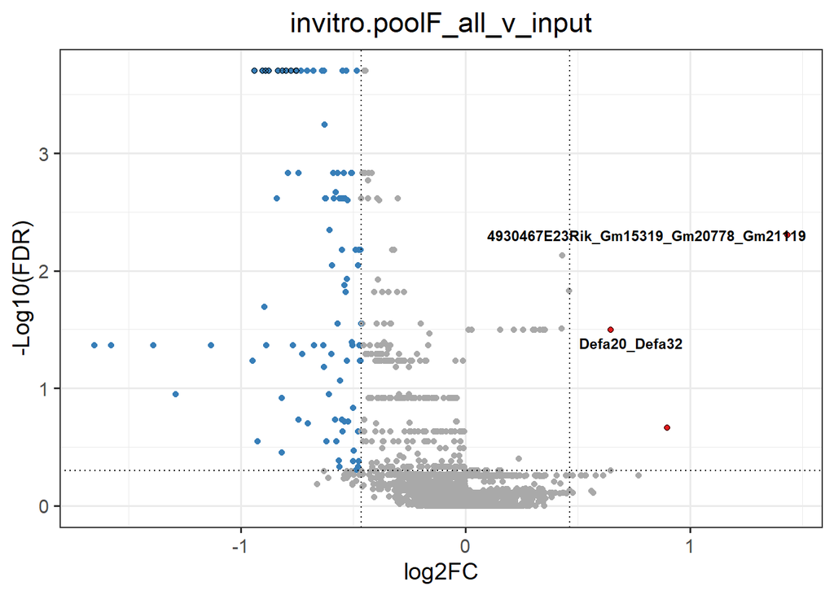

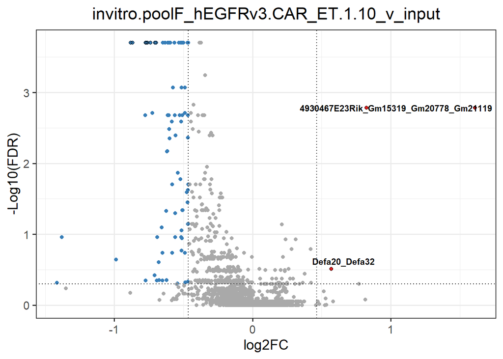

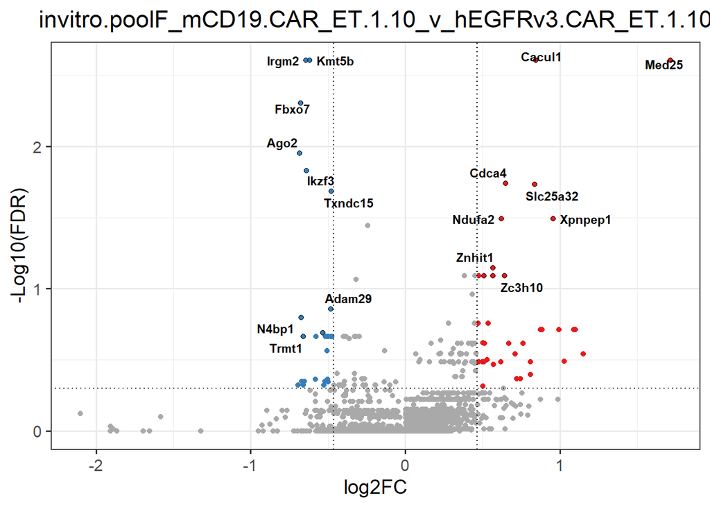

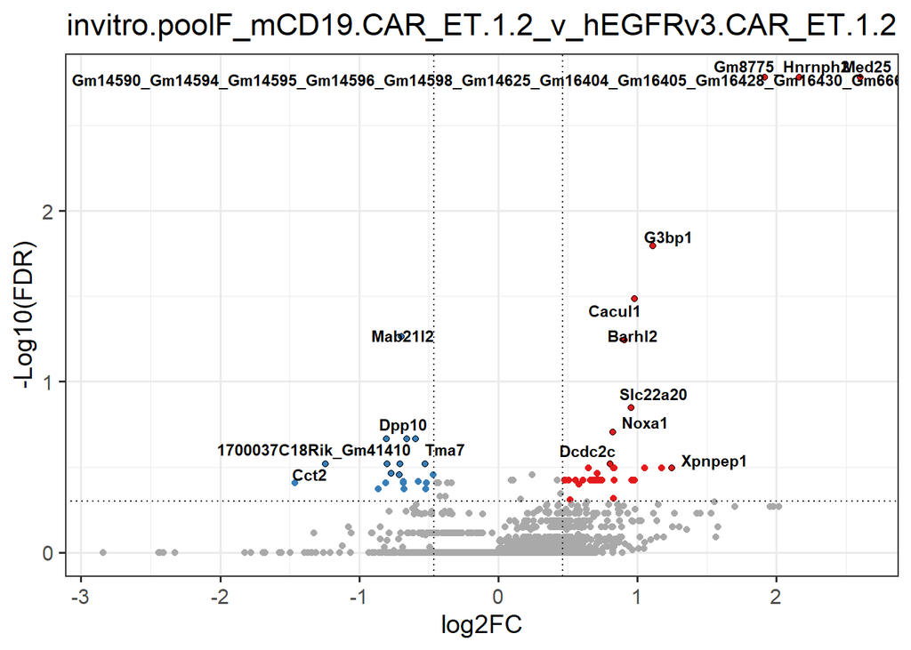

```r
for (i in files.toPlot){
  assign(paste0(i,".gdata"),ReadRRA(paste0(i,".gene_summary.txt"), score = c("lfc", "rra")[1]))
  assign(paste0(i,".sdata"),ReadsgRRA(paste0(i,".sgrna_summary.txt")))
}

for (i in files.toPlot){
  x <- get(paste0(i,".gdata"))
  print(plot_gdata_volcano(x))
}
```

# In Vivo

## In Vivo Pool A

```r
invivo.poolA.1 <- ldf.200406[[1]][c(1,3)]
invivo.poolA.2 <- ldf.200406[[14]][c(1,23,24)]
invivo.poolA.3 <- ldf.200406[[18]][c(1,3,4)]
invivo.poolA.4 <- ldf.200627[[61]][c(1,9,10,11,13,23,24,25,26,27,28,29)]
invivo.poolA.RH <- ldf.RH[[1]][c(1,6,7,8,9,10,11)]

invivo.poolA <- merge(x=invivo.poolA.1,y=invivo.poolA.2, by.x=c("Construct.Barcode"),by.y=c("Construct.Barcode"), all=TRUE)
invivo.poolA <- merge(x=invivo.poolA,y=invivo.poolA.3, by.x=c("Construct.Barcode"),by.y=c("Construct.Barcode"), all=TRUE)
invivo.poolA <- merge(x=invivo.poolA,y=invivo.poolA.4, by.x=c("Construct.Barcode"),by.y=c("Construct.Barcode"), all=TRUE)
invivo.poolA <- merge(x=invivo.poolA,y=invivo.poolA.RH, by.x=c("Construct.Barcode"),by.y=c("Construct.Barcode"), all=TRUE)
invivo.poolA <- merge(x=invivo.poolA,y=sgRNAs.gene, by.x=c("Construct.Barcode"),by.y=c("Barcode.Sequence"), all=FALSE, all.x=TRUE)

col.viv.poolA <- colnames(invivo.poolA)
```

```r
# reorder columns
invivo.poolA.reorder <- invivo.poolA[,c(1,24,2,
                                3,5,18,20,22,
                                11,13,16,
                                7,8,9,10,
                                4,6,19,21,23,
                                12,14,15,17)]

# replace NA values with 0
invivo.poolA.reorder <- replace(invivo.poolA.reorder, is.na(invivo.poolA.reorder), 0)
# Write to table for mageck run
write_delim(invivo.poolA.reorder,file="invivo.poolA.txt", delim = '\t')
```

### results import and plotting

```r
files.toPlot <- list.files(pattern=glob2rx("invivo.poolA_*gene_summary.txt"), full.names=FALSE)
files.toPlot <- str_replace(files.toPlot, ".gene_summary.txt", "")
files.toPlot
```

```
## [1] "invivo.poolA_all_v_input"
## [2] "invivo.poolA_BM_hEGFRv3_15m_v_input"
## [3] "invivo.poolA_BM_mCD19_10m_v_BM_hEGFRv3_15m"
## [4] "invivo.poolA_BM_mCD19_15m_v_BM_hEGFRv3_15m"
## [5] "invivo.poolA_SP_mCD19_10m_v_SP_hEGFRv3_15m"
```

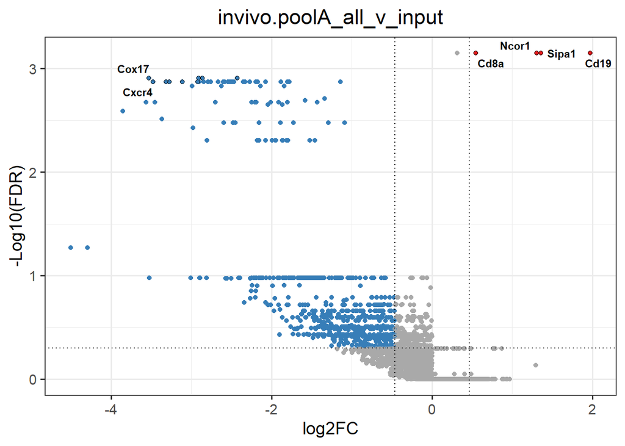

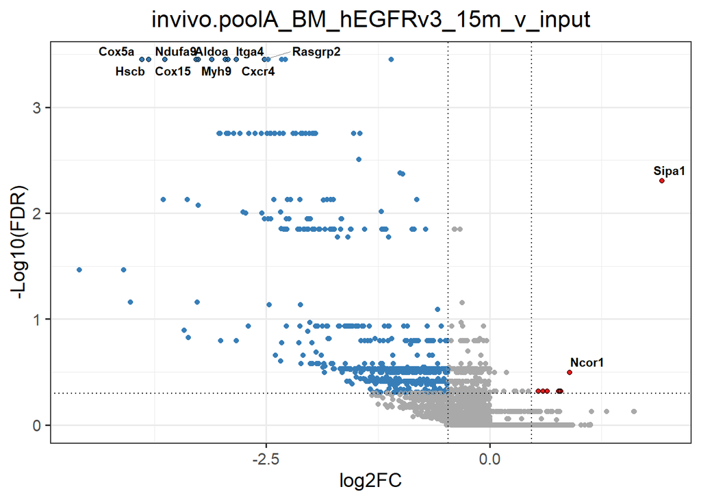

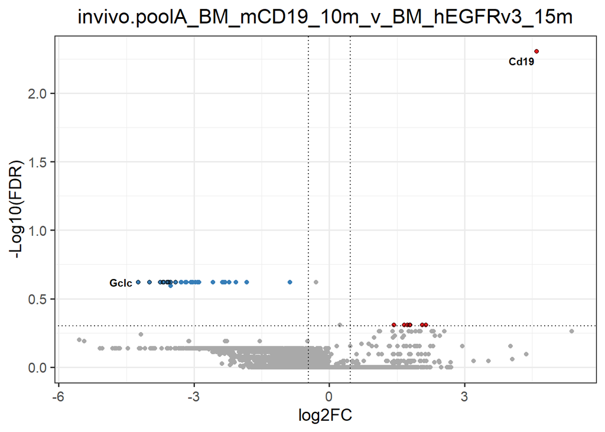

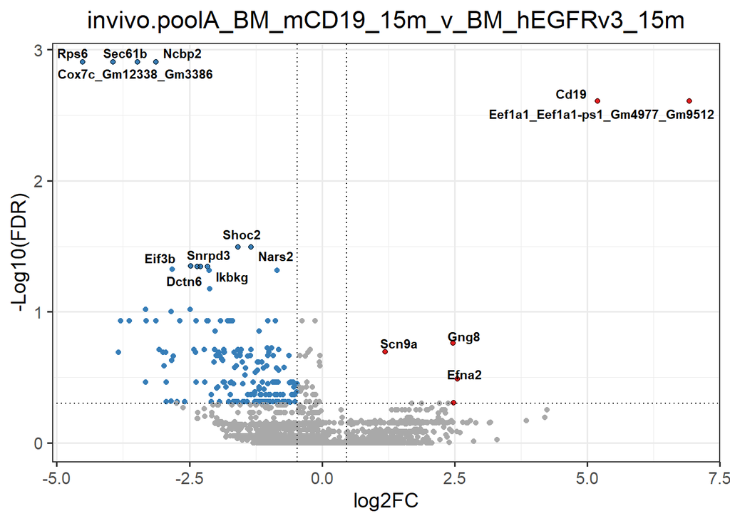

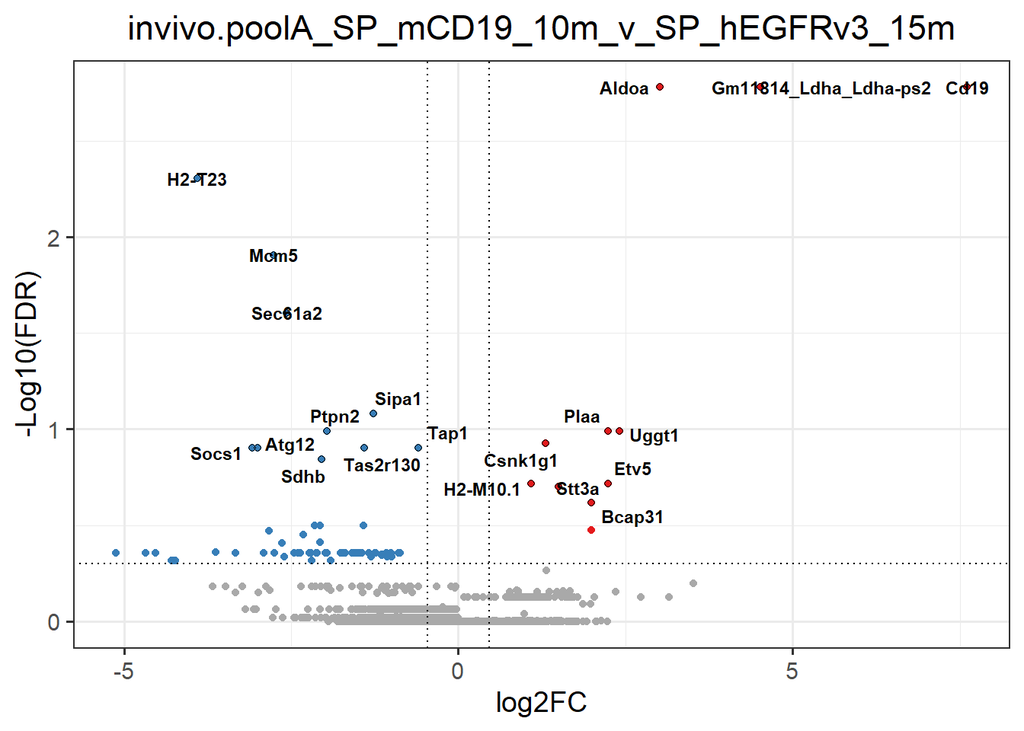

```r
for (i in files.toPlot){
  assign(paste0(i,".gdata"),ReadRRA(paste0(i,".gene_summary.txt"), score = c("lfc", "rra")[1]))
  assign(paste0(i,".sdata"),ReadsgRRA(paste0(i,".sgrna_summary.txt")))
}

for (i in files.toPlot){
  x <- get(paste0(i,".gdata"))
  print(plot_gdata_volcano(x))
}
```